# MIM/PIBO Analysis

Samuel W Wilson

Load in the field data and correct the naming of the Cow Creek sites

```r
field.data = read.csv('C:/Users/samwi/OneDrive - University of Idaho/SalmonFieldData_combined.csv')

for(i in 1:nrow(field.data)){
  if(field.data[i,4]=='092-02-K'){
    field.data[i,2] = 'Lower Cow Creek 02-K'
  }
  if(field.data[i,4]=='092-02-I'){
    field.data[i,2] = 'Lower Cow Creek 02-I'
  }
}
```

For combining field data protocols, this summarises the data for when there were multiple measures for a single year This also filters out pastures that have less than 4 observations

```r
field.sum = field.data %>%
  group_by(MIM.siteName,PIBO.siteName,Year) %>%
  summarise(#MIM.siteName = MIM.siteName,
            #PIBO.siteName = PIBO.siteName,
            Unique = paste0(first(MIM.siteName),'_',first(PIBO.siteName)),
            Allotment = first(Allotment),
            Pasture = first(Pasture),
            GGW = mean(GGW),
            bankfull.width = mean(bankfull.width),
            D50 = mean(D50),
            percent.fines = mean(percent.fines),
            covered.stable = mean(covered.stable),
            stable = mean(stable),
            wetland.rating = mean(wetland.rating)) %>%
  group_by(MIM.siteName,PIBO.siteName) %>%
  filter(n() > 3)
```

Manipulate the data and loop through each pasture performing a MannKendall test to identify significant trends.

```r
# Get a list of all pastures that we have data for
pasts = unique(field.sum$Unique)
# create columns for the p-values to be stored by pasture and by metric
field.sum[c('GGW.MK','bankfull.width.MK','D50.MK',
            'percent.fines.MK','covered.stable.MK','stable.MK',
            'wetland.rating.MK')] = 0
measures = c('GGW','bankfull.width','D50','percent.fines',
             'covered.stable','stable','wetland.rating')

# Loop through each metric for each pasture and perform a MannKendall test
# to identify significant trends
# return NA if too few observations
for(i in pasts){
  locs = which(field.sum$Unique == i)
  df.lim = field.sum[locs,]
  for(k in measures){
    pvalue = ifelse(
      isTRUE(grep('WARNING',capture.output(MannKendall(unlist(df.lim[k]))))==1),
      NA,
      MannKendall(unlist(df.lim[k]))$sl
    )
    co = paste0(k,'.MK')
    field.sum[locs,co] = pvalue
  }
}
```

This chunk was used to create the plots for the original trend analysis.

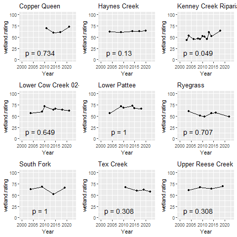

Wetland Rating Significant Trends: Kenney Creek Riparian (Exclosure)

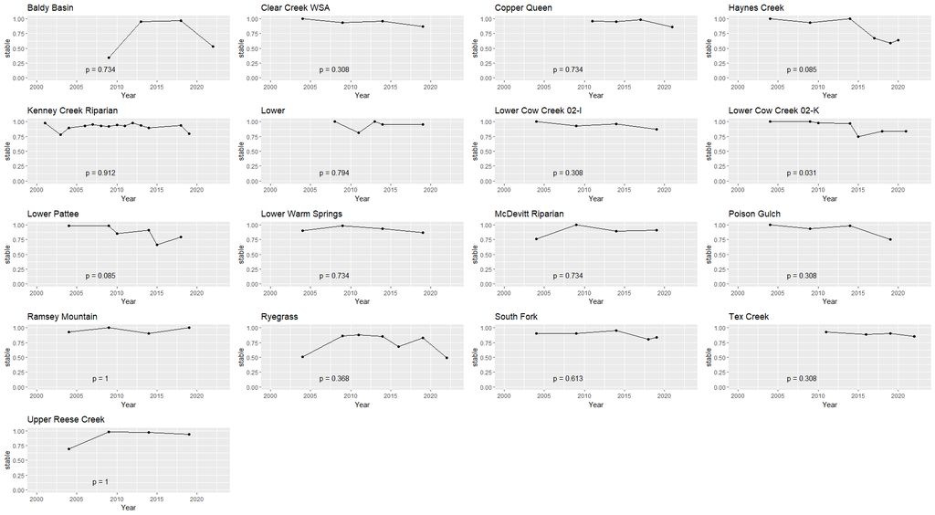

Stable Bank Significant Trends: Haynes Creek (Summer), Lower Pattee (NA), Lower Cow Creek 02-K (Early)

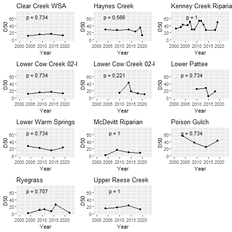

D50 Significant Trends: None

[figure not shown]

```r
# Create a plot item for each pasture and metric, graphing the metric over time
# also adding text about the significance of the relationship for each graph
plot_list <- lapply(split(field.sum, field.sum$Pasture), function(x)
{
  #if(is.na(x$wetland.rating.MK[1])){
  #  print('skip')
  #}
  if(!is.na(x$percent.fines.MK[1])){
    print("don't skip")
    ggplot(x, aes(Year, percent.fines)) +
    geom_line(data=x[!is.na(x$percent.fines),]) +
    geom_point() +
    ylim(0,1) +
    xlim(2000,2023)+
    ggtitle(x$Pasture)+
    annotate('text',x = 2008,y=.15,label = paste0('p = ',round(x$percent.fines.MK[1],3)),size=4)}
  else{NA}
})
plot_list = plot_list[!is.na(plot_list)]
#for(i in 1:length(plot_list)){print(plot_list[[i]])}
# Loop through each graph item and save it to the relevant folder
#for(i in 1:length(plot_list)){
#  title = plot_list[[i]]$data$Pasture[1]
#  png(paste0('C:/Users/Sam/OneDrive - University of Idaho/UI_ResearchTech/MannKendall_fieldData/wetland.rating/',title,'.png'))
#  print(plot_list[[i]])
#  dev.off()
#}

rows = ceiling(length(plot_list)/3)
#png('C:/Users/Sam/OneDrive - University of Idaho/UI_ResearchTech/MannKendall_fieldData/percent.fines/combined.png')
#ggarrange(plot_list[[1]],ncol = 1, nrow = rows)
#dev.off()
```

Almost all sites across treatments had non-significant trends

## Now I’m going to start over and perform NMDS

Read in treatment data

```r
field.data = read.csv('C:/Users/samwi/OneDrive - University of Idaho/SalmonFieldData_combined.csv')

for(i in 1:nrow(field.data)){
  if(field.data[i,4]=='092-02-K'){
    field.data[i,2] = 'Lower Cow Creek 02-K'
  }
  if(field.data[i,4]=='092-02-I'){
    field.data[i,2] = 'Lower Cow Creek 02-I'
  }
}

# For combining field data protocols, this summarises the data for when there were multiple
# measures for a single year
# also filter out pastures that have less than 4 observations
field.sum = field.data %>%
  group_by(MIM.siteName,PIBO.siteName,Year) %>%
  summarise(#MIM.siteName = MIM.siteName,
    #PIBO.siteName = PIBO.siteName,
    Unique = paste0(first(MIM.siteName),'_',first(PIBO.siteName)),
    Allotment = first(Allotment),
    Pasture = first(Pasture),
    GGW = mean(GGW),
    bankfull.width = mean(bankfull.width),
    D50 = mean(D50),
    percent.fines = mean(percent.fines),
    covered.stable = mean(covered.stable),
    stable = mean(stable),
    wetland.rating = mean(wetland.rating))
treatments = read.csv('C:/Users/samwi/OneDrive - University of Idaho/salmonFieldData_treatments.csv')

field.sum.treat = field.sum %>% left_join(treatments, join_by(Allotment == Allotment, Pasture == Pasture))
field.sum.treat$Treatment = ifelse(field.sum.treat$Treatment == '',
                                   NA,
                                   field.sum.treat$Treatment)

field.sum.treat = field.sum.treat[!is.na(field.sum.treat$Treatment),]
```

```r
nmds.field = field.sum.treat
nmds.field = nmds.field[!is.na(nmds.field$bankfull.width),]
nmds.field = nmds.field[!is.na(nmds.field$D50),]
nmds.field = nmds.field[!is.na(nmds.field$stable),]
nmds.field = nmds.field[!is.na(nmds.field$wetland.rating),]

#com = nmds.field[,c(8,9,11)]
com = nmds.field[,c(8,9,11,13)]
#turn abundance data frame into a matrix
m_com = as.matrix(com)

set.seed(123)
nmds = metaMDS(m_com, distance = "bray")
```

```
## Square root transformation
## Wisconsin double standardization
## *** Best solution repeated 8 times
```

```r
nmds
```

```
##
## Call:
## metaMDS(comm = m_com, distance = "bray")
##
## global Multidimensional Scaling using monoMDS
##
## Data:     wisconsin(sqrt(m_com))
## Distance: bray
##
## Dimensions: 2
## Stress:     0.0926303
## Stress type 1, weak ties
## Best solution was repeated 8 times in 20 tries
## The best solution was from try 9 (random start)
## Scaling: centring, PC rotation, halfchange scaling
## Species: expanded scores based on 'wisconsin(sqrt(m_com))'
```

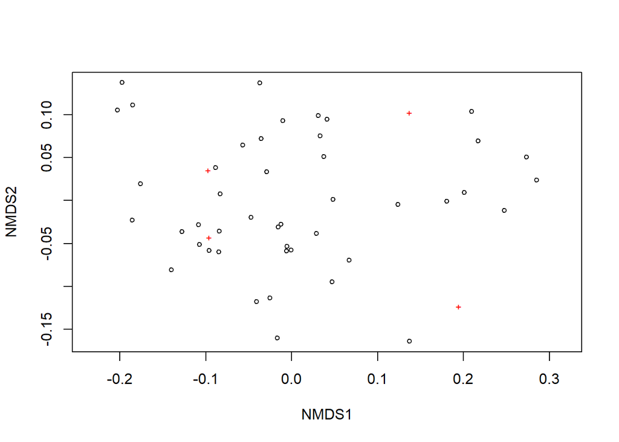

```r
plot(nmds)
```

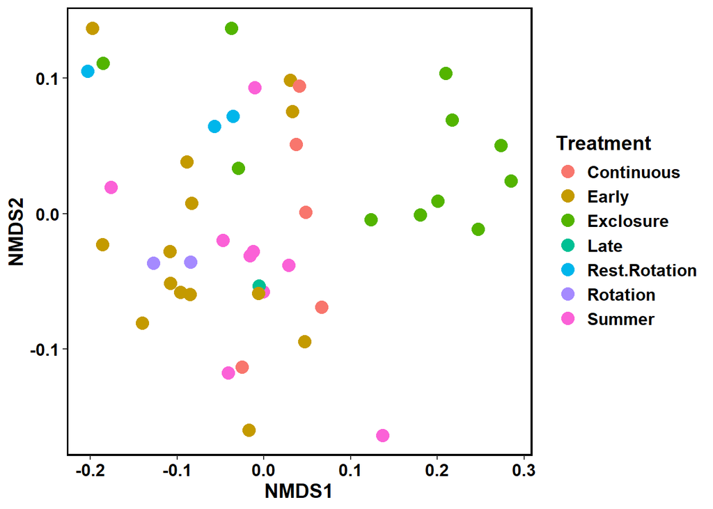

```r
#extract NMDS scores (x and y coordinates) for sites from newer versions of vegan package
data.scores = as.data.frame(scores(nmds)$sites)

#add columns to data frame
data.scores$Treatment = nmds.field$Treatment

ggplot(data.scores, aes(x = NMDS1, y = NMDS2)) +
  geom_point(size = 4, aes(colour = Treatment)) +
  theme(axis.text.y = element_text(colour = "black", size = 12, face = "bold"),
        axis.text.x = element_text(colour = "black", face = "bold", size = 12),
        legend.text = element_text(size = 12, face ="bold", colour ="black"),
        legend.position = "right", axis.title.y = element_text(face = "bold", size = 14),
        axis.title.x = element_text(face = "bold", size = 14, colour = "black"),
        legend.title = element_text(size = 14, colour = "black", face = "bold"),
        panel.background = element_blank(),
        panel.border = element_rect(colour = "black", fill = NA, size = 1.2),
        legend.key=element_blank()) +
  labs(x = "NMDS1", colour = "Treatment", y = "NMDS2")
```

```r
#ordiplot(nmds,type="n")
#ordihull(nmds,groups=data.scores$Treatment,draw="polygon",col="grey90",label=F)
#orditorp(nmds,display = 'sites',col="red",air=0.01)

#ordiplot(nmds,type="n")
#ordiellipse(nmds,groups=data.scores$Treatment,draw="polygon",col="grey90",label=F)
#orditorp(nmds,display = 'sites',col="red",air=0.01)
```

## Now we can use permanova to test for a difference between groups in this space. If there is a difference, we can use betadisper to see if the difference is in the dispersion of the groups. If not, then it is likely the difference is more in the centroids of the groups.

```r
# lets use a permanova to see if there is a difference between groups in this space
adonis2(data.scores[,c('NMDS1','NMDS2')] ~ data.scores$Treatment,
        method = 'euc') # p = 0.001 significant difference
```

```
## Permutation test for adonis under reduced model
## Permutation: free
## Number of permutations: 999
##
## adonis2(formula = data.scores[, c("NMDS1", "NMDS2")] ~ data.scores$Treatment, method = "euc")
##          Df SumOfSqs      R2      F Pr(>F)
## Model     6  0.39941 0.41037 4.4079  0.001 ***
## Residual 38  0.57387 0.58963
## Total    44  0.97328 1.00000
## ---
## Signif. codes:  0 '***' 0.001 '**' 0.01 '*' 0.05 '.' 0.1 ' ' 1
```

```r
# we will use betadisper to see if there is significant differnce between dispersion
# if not then the permanova is likely pointing to differences in centroids

# use the betadisper function from 'vegan' to measure the distances between points
# and the centroid of their group
ordinationDist = betadisper(d = dist(data.scores[,c('NMDS1','NMDS2')]),
                            group = data.scores$Treatment,
                            type = 'centroid')
ordinationDist$distances
```

```
##          1          2          3          4          5          6          7
## 0.04642519 0.15174927 0.05908681 0.15558626 0.14053919 0.10722593 0.06344986
##          8          9         10         11         12         13         14
## 0.04445678 0.01672723 0.05854034 0.10179779 0.32646474 0.16490119 0.19419906
##         15         16         17         18         19         20         21
## 0.17074413 0.14117067 0.04346639 0.03796682 0.02848104 0.12133331 0.02165706
##         22         23         24         25         26         27         28
## 0.02165706 0.08340826 0.02441067 0.04418436 0.01067850 0.13821945 0.06645844
##         29         30         31         32         33         34         35
## 0.07599278 0.05332417 0.08495179 0.15171636 0.12670863 0.09347030 0.00000000
##         36         37         38         39         40         41         42
## 0.09254595 0.13123201 0.03715128 0.00724001 0.19994028 0.04877367 0.11408250
##         43         44         45
## 0.07710613 0.07034799 0.19756901
```

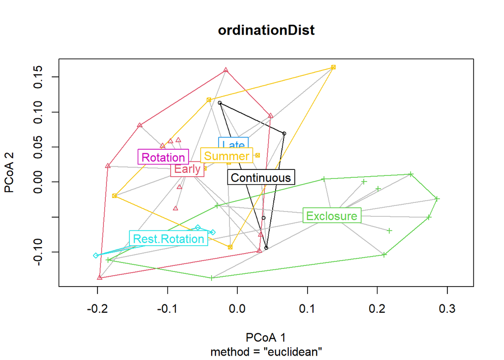

```r
plot(ordinationDist)
```

```r
# is there a difference in dispersion between groups?
anova(ordinationDist) #p-value equals 0.12
```

```
## Analysis of Variance Table
##
## Response: Distances
##           Df   Sum Sq   Mean Sq F value Pr(>F)
## Groups     6 0.042674 0.0071124  1.8138 0.1224
## Residuals 38 0.149005 0.0039212
```

```r
adonis2(dist(ordinationDist$distances) ~ data.scores$Treatment) #p = 0.14
```

```
## Permutation test for adonis under reduced model
## Permutation: free
## Number of permutations: 999
##
## adonis2(formula = dist(ordinationDist$distances) ~ data.scores$Treatment)
##          Df SumOfSqs      R2      F Pr(>F)
## Model     6 0.042674 0.22263 1.8138   0.14
## Residual 38 0.149005 0.77737
## Total    44 0.191679 1.00000
```

```r
#TukeyHSD(ordinationDist) # no significant differences between any groups in dispersion
```

## I am concerned that the lack of samples in a few groups might be influencing things, going to drop rest-rotation,rotation, and late and repeat the process

```r
#

data.scores = data.scores[data.scores$Treatment!= 'Late',]
data.scores = data.scores[data.scores$Treatment!= 'Rest.Rotation',]
data.scores = data.scores[data.scores$Treatment!= 'Rotation',]

# lets use a permanova to see if there is a difference between groups in this space
adonis2(data.scores[,c('NMDS1','NMDS2')] ~ data.scores$Treatment,
        method = 'euc') # p = 0.001 significant difference
```

```
## Permutation test for adonis under reduced model
## Permutation: free
## Number of permutations: 999
##
## adonis2(formula = data.scores[, c("NMDS1", "NMDS2")] ~ data.scores$Treatment, method = "euc")
##          Df SumOfSqs      R2      F Pr(>F)
## Model     3  0.31590 0.36254 6.6353  0.001 ***
## Residual 35  0.55544 0.63746
## Total    38  0.87133 1.00000
## ---
## Signif. codes:  0 '***' 0.001 '**' 0.01 '*' 0.05 '.' 0.1 ' ' 1
```

```r
# use the betadisper function from 'vegan' to measure the distances between points
# and the centroid of their group
ordinationDist = betadisper(d = dist(data.scores[,c('NMDS1','NMDS2')]),
                            group = data.scores$Treatment,
                            type = 'centroid')
ordinationDist$distances
```

```
##          1          2          3          4          5          9         10
## 0.04642519 0.15174927 0.05908681 0.15558626 0.14053919 0.01672723 0.05854034
##         11         12         13         14         15         16         17
## 0.10179779 0.32646474 0.16490119 0.19419906 0.17074413 0.14117067 0.04346639
##         18         19         20         23         24         25         26
## 0.03796682 0.02848104 0.12133331 0.08340826 0.02441067 0.04418436 0.01067850
##         27         28         29         30         31         32         33
## 0.13821945 0.06645844 0.07599278 0.05332417 0.08495179 0.15171636 0.12670863
##         34         36         37         38         39         40         41
## 0.09347030 0.09254595 0.13123201 0.03715128 0.00724001 0.19994028 0.04877367
##         42         43         44         45
## 0.11408250 0.07710613 0.07034799 0.19756901
```

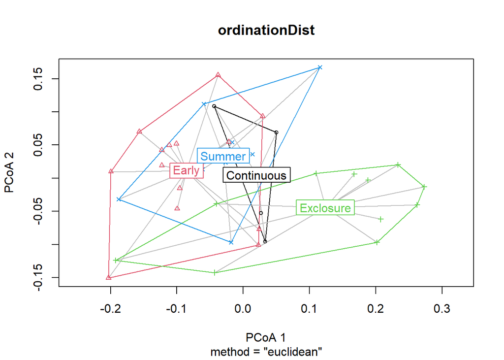

```r
plot(ordinationDist)
```

```r
# is there a difference in dispersion between groups?
anova(ordinationDist) #p= 0.18
```

```
## Analysis of Variance Table
##
## Response: Distances
##           Df   Sum Sq   Mean Sq F value Pr(>F)
## Groups     3 0.020762 0.0069206  1.6485 0.1959
## Residuals 35 0.146932 0.0041981
```

```r
adonis2(dist(ordinationDist$distances) ~ data.scores$Treatment) #p = 0.17
```

```
## Permutation test for adonis under reduced model
## Permutation: free
## Number of permutations: 999
##
## adonis2(formula = dist(ordinationDist$distances) ~ data.scores$Treatment)
##          Df SumOfSqs      R2      F Pr(>F)
## Model     3 0.020762 0.12381 1.6485   0.19
## Residual 35 0.146932 0.87619
## Total    38 0.167694 1.00000
```

## Based on the above results it appears that the difference lies in the centroids of the groups and not in the dispersion of the groups and small sample sizes for some of the groups is not throwing that off.

## Now look at just beginning and end data to get an idea of effect size

```r
field.data = read.csv('C:/Users/samwi/OneDrive - University of Idaho/SalmonFieldData_combined.csv')
treatments = read.csv('C:/Users/samwi/OneDrive - University of Idaho/salmonFieldData_treatments.csv')
for(i in 1:nrow(field.data)){
  if(field.data[i,4]=='092-02-K'){
    field.data[i,2] = 'Lower Cow Creek 02-K'
  }
  if(field.data[i,4]=='092-02-I'){
    field.data[i,2] = 'Lower Cow Creek 02-I'
  }
}

field.sum = field.data %>%
  group_by(MIM.siteName,PIBO.siteName,Year) %>%
  summarise(#MIM.siteName = MIM.siteName,
    #PIBO.siteName = PIBO.siteName,
    Unique = paste0(first(MIM.siteName),'_',first(PIBO.siteName)),
    Allotment = first(Allotment),
    Pasture = first(Pasture),
    GGW = mean(GGW),
    bankfull.width = mean(bankfull.width),
    D50 = mean(D50),
    percent.fines = mean(percent.fines),
    covered.stable = mean(covered.stable),
    stable = mean(stable),
    wetland.rating = mean(wetland.rating)) %>%
  group_by(MIM.siteName,PIBO.siteName)
field.sum.treat = field.sum %>% left_join(treatments, join_by(Allotment == Allotment, Pasture == Pasture))
field.sum.treat$Treatment = ifelse(field.sum.treat$Treatment == '',
                                   NA,
                                   field.sum.treat$Treatment)
field.sum.treat = field.sum.treat[!is.na(field.sum.treat$Treatment),]


past_list = unique(field.sum.treat$Unique)

find.change = function(list){
  list2 = na.omit(list)
  if(length(list2) == 0){
    return(NA)
  }else{
  list.length = length(list2)
  list.change = list2[list.length] - list2[1]
  return(list.change)}
}
# positive means increase, negative means decrease
change.df = data.frame(unique = character(),
                       Treatment = character(),
                       years = numeric(),
                       bankfull.width = numeric(),
                       D50 = numeric(),
                       stable = numeric(),
                       wetland.rating = numeric())
for(i in past_list){
  df.limit = field.sum.treat[field.sum.treat$Unique == i,]
  graze = df.limit$Treatment[1]
  year.change = find.change(df.limit$Year)
  bankfull.width.change = find.change(df.limit$bankfull.width)
  D50.change = find.change(df.limit$D50)
  stable.change = find.change(df.limit$stable)
  wetland.change = find.change(df.limit$wetland.rating)
  df.new = data.frame(unique = i,
                      Treatment = graze,
                      years = year.change,
                      bankfull.width = bankfull.width.change,
                      D50 = D50.change,
                      stable = stable.change,
                      wetland.rating = wetland.change)
  change.df = rbind(change.df,df.new)
}
```

```r
# too few observations for these two treatments to justify keeping them
change.df = change.df[change.df$Treatment!= 'Rotation',]
change.df = change.df[change.df$Treatment!= 'Rest.Rotation',]
change.df = change.df[change.df$Treatment!= 'Late',]

adonis2(change.df[,3:6] ~ change.df$Treatment, na.rm = T,
        method = 'euc') # p = 0.07 significant difference
```

```
## Permutation test for adonis under reduced model
## Permutation: free
## Number of permutations: 999
##
## adonis2(formula = change.df[, 3:6] ~ change.df$Treatment, method = "euc", na.rm = T)
##          Df SumOfSqs      R2      F Pr(>F)
## Model     3   1773.2 0.39688 2.8516  0.084 .
## Residual 13   2694.5 0.60312
## Total    16   4467.7 1.00000
## ---
## Signif. codes:  0 '***' 0.001 '**' 0.01 '*' 0.05 '.' 0.1 ' ' 1
```

```r
#ggplot(change.df, aes(x = Treatment, y = bankfull.width)) +
#  geom_boxplot()

#ggplot(change.df, aes(x = Treatment, y = D50)) +
#  geom_boxplot()

#ggplot(change.df, aes(x = Treatment, y = stable)) +
#  geom_boxplot()

#ggplot(change.df, aes(x = Treatment, y = wetland.rating)) +
#  geom_boxplot()
```

```r
summary(aov(change.df$bankfull.width ~ change.df$Treatment)) #p = 0.68
```

```
##                     Df Sum Sq Mean Sq F value Pr(>F)
## change.df$Treatment  3  0.527  0.1757   0.514   0.68
## Residuals           12  4.103  0.3420
## 1 observation deleted due to missingness
```

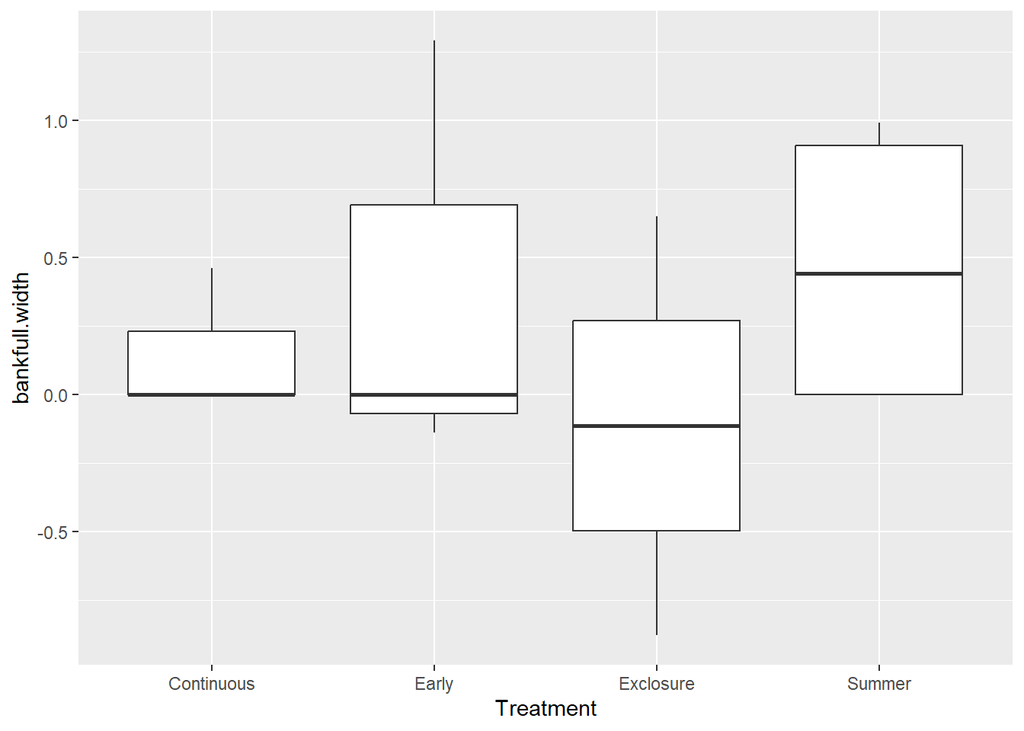

```r
ggplot(change.df, aes(x = Treatment, y = bankfull.width)) +
  geom_boxplot()
```

```r
summary(aov(change.df$D50 ~ change.df$Treatment)) #p = 0.07
```

```
##                     Df Sum Sq Mean Sq F value Pr(>F)
## change.df$Treatment  3   1743   580.9   2.988   0.07 .
## Residuals           13   2527   194.4
## ---
## Signif. codes:  0 '***' 0.001 '**' 0.01 '*' 0.05 '.' 0.1 ' ' 1
```

```r
TukeyHSD(aov(change.df$D50 ~ change.df$Treatment)) # summer and exclosure are the only likely differences
```

```
##   Tukey multiple comparisons of means
##     95% family-wise confidence level
##
## Fit: aov(formula = change.df$D50 ~ change.df$Treatment)
##
## $`change.df$Treatment`
##                            diff       lwr       upr     p adj
## Early-Continuous      12.809048 -15.43097 41.049068 0.5605675
## Exclosure-Continuous  23.163333 -14.19470 60.521368 0.3079937
## Summer-Continuous     -6.016667 -35.90309 23.869761 0.9330602
## Exclosure-Early       10.354286 -22.45765 43.166224 0.7915801
## Summer-Early         -18.825714 -42.78817  5.136737 0.1471794
## Summer-Exclosure     -29.180000 -63.41920  5.059205 0.1064053
```

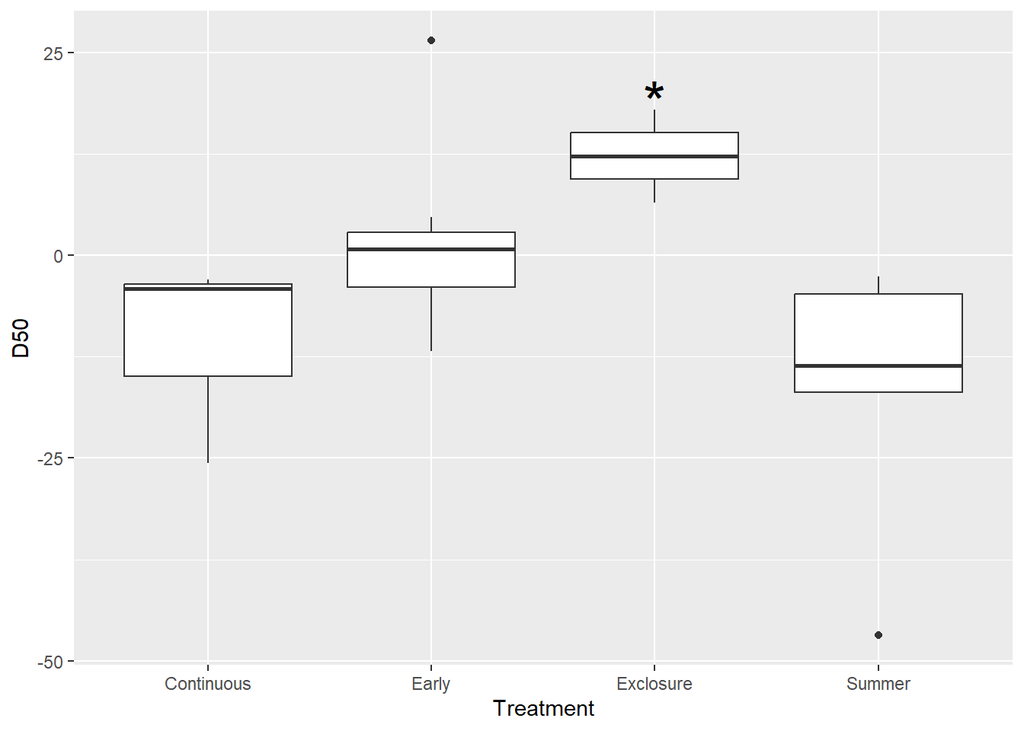

```r
ggplot(change.df, aes(x = Treatment, y = D50)) +
  geom_boxplot()+
  annotate('text',x = 'Exclosure',y=19,label = '*',
           size = 10)
```

```r
summary(aov(change.df$stable ~ change.df$Treatment)) #p = 0.979
```

```
##                     Df Sum Sq  Mean Sq F value Pr(>F)
## change.df$Treatment  3 0.0053 0.001775   0.062  0.979
## Residuals           13 0.3750 0.028844
```

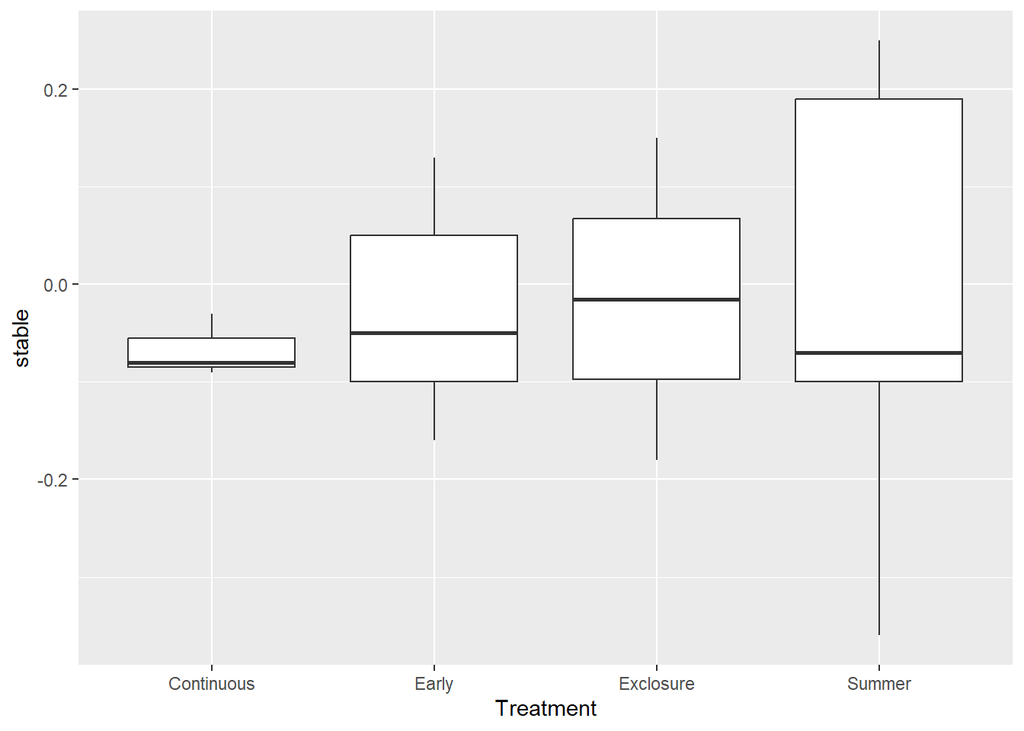

```r
ggplot(change.df, aes(x = Treatment, y = stable)) +
  geom_boxplot()
```

```r
summary(aov(change.df$wetland.rating ~ change.df$Treatment)) #p = 0.115
```

```
##                     Df Sum Sq Mean Sq F value Pr(>F)
## change.df$Treatment  3  325.5  108.49   2.393  0.115
## Residuals           13  589.3   45.33
```

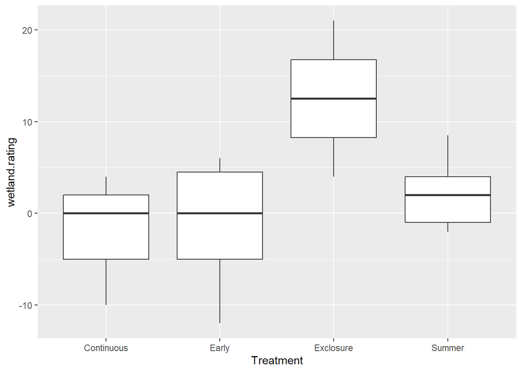

```r
ggplot(change.df, aes(x = Treatment, y = wetland.rating)) +
  geom_boxplot()
```

## Only slightly significant difference lies in D50. However a Tukeys HSD does not show much difference when comparing groups individually. Exclosure and summer are the only groups likely different for D50.